# parametric_regression_pymc3

```python
# make sure the notebook reloads the module each time we modify it
%load_ext autoreload
%autoreload 2

# Uncomment the next line if you want to be able to zoom on plots
# %matplotlib notebook
```

```python
from IPython.display import set_matplotlib_formats
set_matplotlib_formats('retina')
az.style.use("arviz-darkgrid")
```

```python
import parametric_regression as pr
import matplotlib.pyplot as plt
import seaborn as sns
sns.set(style="ticks")
import numpy as np
import pymc3 as pm
import arviz as az
```

## Preparing data and utilities

I've prepared a function to generate regression data $$ y \sim \mathcal{N}(X\theta_{\text{true}}, \sigma^2 I). $$ Check how $\theta_{\text{true}}$ is generated, with a few ``support variables", and the rest of the coordinates close to zero.

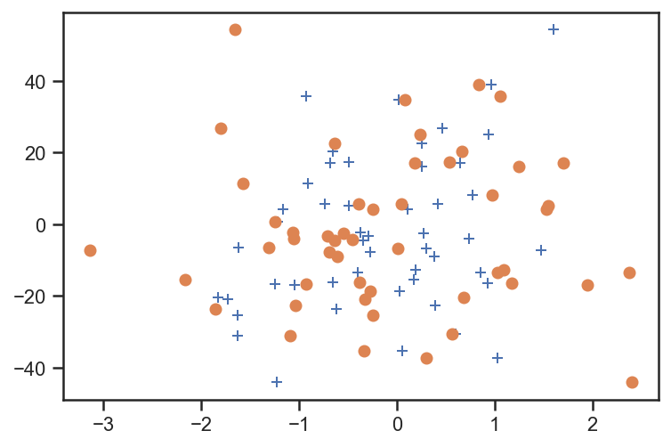

```python
dimension = 100
sample_size = 50
X, y, theta_true, sigma_noise, indices_support = pr.generate_data(sample_size = sample_size,
                                                        dimension = dimension, seed = 3)
plt.plot(X[:,indices_support[0]], y, '+')
plt.plot(X[:,0], y, 'o')
plt.show()
```

I've prepared a function to plot an estimator and the corresponding error bars, and compare it to the underlying true $\theta_{\text{true}}$ in green. The bottom plot is the same, but with $\theta_{\text{true}}$ substracted.

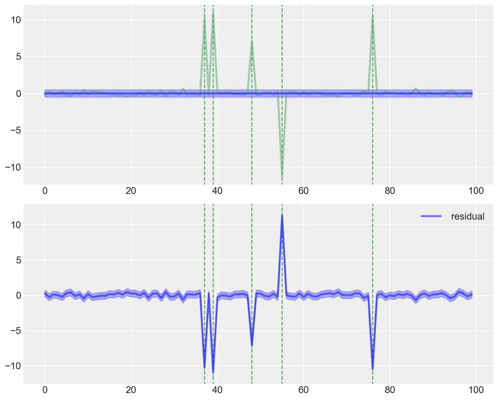

```python
fake_std = .5*np.ones(theta_true.shape)
fake_theta_hat = np.zeros(theta_true.shape)
fig, ax = plt.subplots(2, figsize=(10,8))
pr.plot_coefficients(ax, color="blue", theta_true=theta_true, indices_support=indices_support,
                     theta_hat=fake_theta_hat, lower_bound=fake_theta_hat-fake_std,
                     upper_bound=fake_theta_hat+fake_std)
plt.show()
```

## Using sklearn's lasso implementation as baseline

Your first exercise is to get scikit-learn's lasso estimate as a baseline. Go to the companion Python file, and fill in the corresponding function. Then plot your estimate and comment.

```python
theta_lasso = pr.get_sklearn_lasso_estimate(X, y)
```

```python
np.linalg.norm(y - theta_lasso.dot(X.T))
```

```
5.101803783399101
```

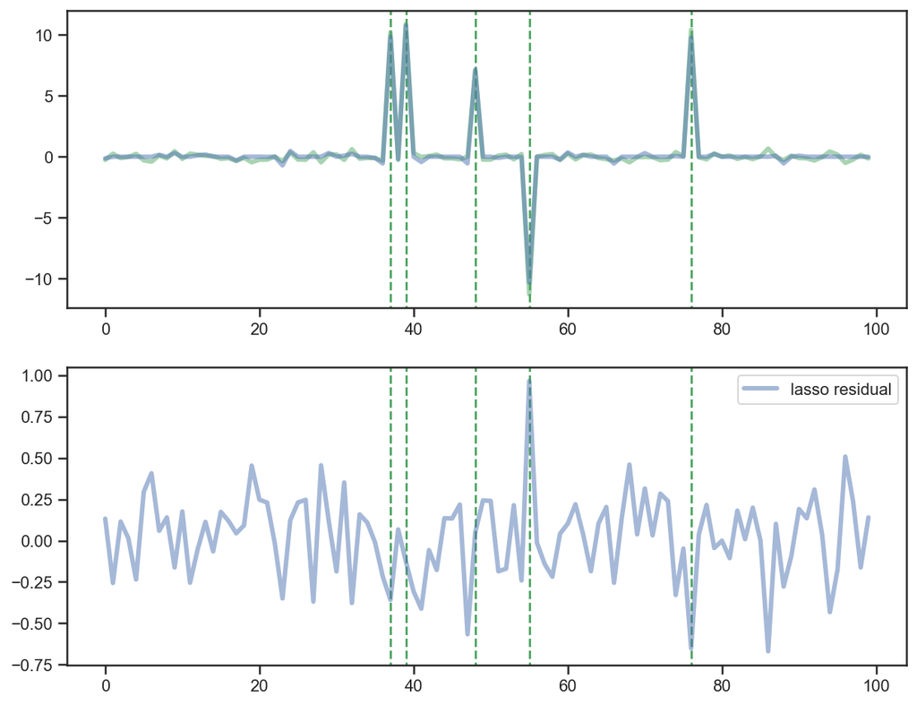

```python
fig, ax = plt.subplots(2, figsize=(10,8))
pr.plot_coefficients(ax, theta_true=theta_true, indices_support=indices_support, theta_hat=theta_lasso, label="lasso")
plt.show()
```

## Bayesian lasso using a Laplace prior

You second exercise is to use `pymc3` to implement Bayesian linear regression with a Laplace prior. Again, fill in the corresponding function in the companion Python file. You should output a `pymc3` Trace object, with the $\theta$ variable of our regression problem named `theta`. Play around with different MCMC kernels.

*Hint*: Remember, the Laplace prior is the one that makes the MAP estimator be the solution to the frequentist Lasso.

```python
trace = pr.get_mcmc_sample_for_laplace_prior(X, y)
accept = np.sum(trace['theta'][1:,0] != trace['theta'][:-1,0])
print("Acceptance Rate: ", accept/trace['theta'][:,0].shape[0])
```

```
Auto-assigning NUTS sampler...
Initializing NUTS using jitter+adapt_diag...
Multiprocess sampling (4 chains in 4 jobs)
NUTS: [theta]
```

100.00% [6000/6000 00:13<00:00 Sampling 4 chains, 0 divergences]

```
Sampling 4 chains for 1_000 tune and 500 draw iterations (4_000 + 2_000 draws total) took 23 seconds.
```

```
Acceptance Rate:  0.9995
```

```python
# Let's check a summary of that trace, find out what the columns mean in the doc
summary = pm.summary(trace)
summary[summary['mean']>5]
```

|  | mean | sd | hdi_3% | hdi_97% | mcse_mean | mcse_sd | ess_mean | ess_sd | ess_bulk | ess_tail | r_hat |
| --- | --- | --- | --- | --- | --- | --- | --- | --- | --- | --- | --- |
| theta[37] | 9.804 | 0.601 | 8.708 | 10.923 | 0.015 | 0.011 | 1544.0 | 1544.0 | 1554.0 | 1181.0 | 1.0 |
| theta[39] | 10.749 | 0.736 | 9.366 | 12.092 | 0.020 | 0.014 | 1341.0 | 1341.0 | 1342.0 | 1300.0 | 1.0 |
| theta[48] | 7.200 | 0.550 | 6.179 | 8.240 | 0.014 | 0.010 | 1547.0 | 1540.0 | 1550.0 | 1152.0 | 1.0 |
| theta[76] | 9.428 | 0.522 | 8.451 | 10.379 | 0.014 | 0.010 | 1396.0 | 1392.0 | 1395.0 | 1450.0 | 1.0 |

```python
summary[np.abs(summary['mean'])<.1]
```

|  | mean | sd | hdi_3% | hdi_97% | mcse_mean | mcse_sd | ess_mean | ess_sd | ess_bulk | ess_tail | r_hat |
| --- | --- | --- | --- | --- | --- | --- | --- | --- | --- | --- | --- |
| theta[1] | 0.039 | 0.421 | -0.819 | 0.809 | 0.010 | 0.010 | 1953.0 | 847.0 | 2031.0 | 1497.0 | 1.00 |
| theta[2] | 0.080 | 0.378 | -0.595 | 0.844 | 0.009 | 0.010 | 1878.0 | 748.0 | 1934.0 | 1209.0 | 1.00 |
| theta[5] | 0.008 | 0.424 | -0.806 | 0.832 | 0.009 | 0.011 | 2061.0 | 760.0 | 2103.0 | 1332.0 | 1.00 |
| theta[6] | -0.044 | 0.367 | -0.749 | 0.667 | 0.009 | 0.009 | 1796.0 | 886.0 | 1842.0 | 1374.0 | 1.01 |
| theta[8] | -0.020 | 0.412 | -0.834 | 0.736 | 0.009 | 0.009 | 2318.0 | 1159.0 | 2373.0 | 1637.0 | 1.00 |
| theta[14] | -0.008 | 0.401 | -0.829 | 0.745 | 0.009 | 0.010 | 2026.0 | 806.0 | 2031.0 | 1386.0 | 1.00 |
| theta[16] | 0.081 | 0.410 | -0.675 | 0.940 | 0.009 | 0.009 | 2059.0 | 1051.0 | 2116.0 | 1491.0 | 1.00 |
| theta[18] | 0.028 | 0.394 | -0.746 | 0.768 | 0.009 | 0.011 | 2151.0 | 633.0 | 2204.0 | 1191.0 | 1.00 |
| theta[20] | 0.067 | 0.427 | -0.733 | 0.925 | 0.011 | 0.011 | 1541.0 | 800.0 | 1659.0 | 1044.0 | 1.00 |
| theta[25] | 0.003 | 0.385 | -0.802 | 0.697 | 0.008 | 0.008 | 2109.0 | 1048.0 | 2149.0 | 1241.0 | 1.00 |
| theta[26] | 0.029 | 0.349 | -0.656 | 0.715 | 0.008 | 0.009 | 1949.0 | 744.0 | 1984.0 | 1103.0 | 1.00 |
| theta[28] | 0.065 | 0.412 | -0.647 | 0.948 | 0.010 | 0.010 | 1617.0 | 802.0 | 1695.0 | 1177.0 | 1.00 |
| theta[30] | 0.097 | 0.434 | -0.743 | 0.935 | 0.010 | 0.012 | 1852.0 | 686.0 | 1891.0 | 929.0 | 1.00 |
| theta[42] | 0.071 | 0.428 | -0.706 | 0.964 | 0.011 | 0.011 | 1480.0 | 764.0 | 1570.0 | 1098.0 | 1.00 |
| theta[44] | -0.035 | 0.433 | -0.856 | 0.789 | 0.010 | 0.012 | 1733.0 | 688.0 | 1789.0 | 1075.0 | 1.00 |
| theta[49] | 0.069 | 0.407 | -0.771 | 0.823 | 0.010 | 0.009 | 1756.0 | 1008.0 | 1777.0 | 1103.0 | 1.00 |
| theta[50] | -0.048 | 0.418 | -0.861 | 0.761 | 0.009 | 0.011 | 2226.0 | 702.0 | 2239.0 | 1266.0 | 1.00 |
| theta[53] | -0.090 | 0.384 | -0.865 | 0.630 | 0.009 | 0.009 | 1929.0 | 893.0 | 1976.0 | 1395.0 | 1.00 |
| theta[57] | -0.005 | 0.401 | -0.847 | 0.734 | 0.009 | 0.010 | 2006.0 | 760.0 | 2075.0 | 1354.0 | 1.00 |
| theta[58] | 0.043 | 0.408 | -0.747 | 0.832 | 0.010 | 0.010 | 1684.0 | 770.0 | 1727.0 | 1271.0 | 1.00 |
| theta[61] | 0.090 | 0.369 | -0.641 | 0.779 | 0.009 | 0.010 | 1757.0 | 733.0 | 1857.0 | 1130.0 | 1.00 |
| theta[63] | -0.005 | 0.363 | -0.753 | 0.664 | 0.009 | 0.009 | 1774.0 | 776.0 | 1807.0 | 1159.0 | 1.01 |
| theta[67] | 0.080 | 0.378 | -0.620 | 0.839 | 0.008 | 0.010 | 2032.0 | 778.0 | 2162.0 | 1083.0 | 1.01 |
| theta[68] | -0.055 | 0.386 | -0.786 | 0.685 | 0.009 | 0.010 | 1797.0 | 724.0 | 1920.0 | 1149.0 | 1.01 |
| theta[69] | 0.003 | 0.327 | -0.635 | 0.612 | 0.008 | 0.008 | 1614.0 | 890.0 | 1635.0 | 1289.0 | 1.01 |
| theta[72] | -0.061 | 0.395 | -0.883 | 0.665 | 0.009 | 0.009 | 1890.0 | 868.0 | 1952.0 | 1268.0 | 1.00 |
| theta[73] | -0.009 | 0.368 | -0.753 | 0.704 | 0.008 | 0.009 | 2019.0 | 819.0 | 2056.0 | 1324.0 | 1.00 |
| theta[74] | 0.072 | 0.385 | -0.692 | 0.792 | 0.009 | 0.008 | 1838.0 | 1036.0 | 1867.0 | 1093.0 | 1.00 |
| theta[78] | -0.023 | 0.386 | -0.760 | 0.725 | 0.010 | 0.009 | 1608.0 | 859.0 | 1611.0 | 1291.0 | 1.00 |
| theta[79] | 0.058 | 0.395 | -0.717 | 0.817 | 0.010 | 0.010 | 1645.0 | 833.0 | 1707.0 | 1193.0 | 1.00 |
| theta[80] | 0.093 | 0.436 | -0.713 | 0.966 | 0.011 | 0.011 | 1602.0 | 744.0 | 1666.0 | 1132.0 | 1.00 |
| theta[81] | -0.011 | 0.336 | -0.623 | 0.644 | 0.008 | 0.008 | 1899.0 | 970.0 | 1991.0 | 1184.0 | 1.00 |
| theta[82] | -0.039 | 0.448 | -0.940 | 0.843 | 0.011 | 0.012 | 1731.0 | 719.0 | 1786.0 | 1119.0 | 1.00 |
| theta[86] | 0.017 | 0.456 | -0.758 | 1.042 | 0.010 | 0.011 | 2146.0 | 797.0 | 2165.0 | 1246.0 | 1.00 |
| theta[87] | 0.096 | 0.478 | -0.749 | 1.110 | 0.012 | 0.013 | 1658.0 | 646.0 | 1712.0 | 1034.0 | 1.00 |
| theta[89] | -0.019 | 0.392 | -0.703 | 0.840 | 0.009 | 0.010 | 1706.0 | 801.0 | 1833.0 | 1155.0 | 1.00 |
| theta[91] | 0.017 | 0.375 | -0.699 | 0.771 | 0.009 | 0.010 | 1868.0 | 660.0 | 1896.0 | 1269.0 | 1.00 |
| theta[95] | 0.067 | 0.409 | -0.680 | 0.908 | 0.010 | 0.009 | 1802.0 | 1030.0 | 1955.0 | 1178.0 | 1.00 |
| theta[99] | -0.094 | 0.387 | -0.906 | 0.594 | 0.009 | 0.010 | 1777.0 | 782.0 | 1848.0 | 1035.0 | 1.00 |

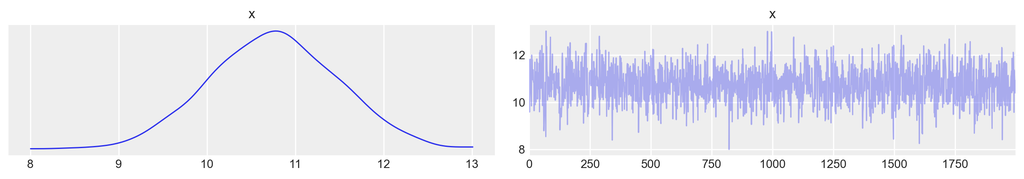

```python
# Plot here a few trajectories of the chain corresponding to a variable in the support.
az.plot_trace(trace['theta'][:,39])
plt.show()
```

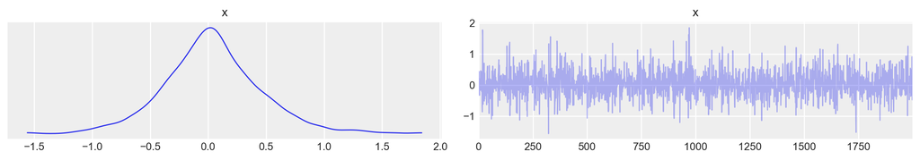

```python
# Plot here a few trajectories of the chain corresponding to a variable out of the support.
az.plot_trace(trace['theta'][:,1])
plt.show()
```

```python
l2_norm = np.array([np.linalg.norm(y - trace["theta"][i].dot(X.T)) for i in range(trace["theta"].shape[0])])
np.min(l2_norm)
```

```
4.952299020516781
```

```python
theta_laplace = np.mean(trace["theta"], axis=0) #trace['theta'][np.argmin(l2_norm)] # not expected to show much sparsity
lower_bound_laplace = np.percentile(trace["theta"],5, axis=0)
upper_bound_laplace = np.percentile(trace["theta"],95, axis=0)
```

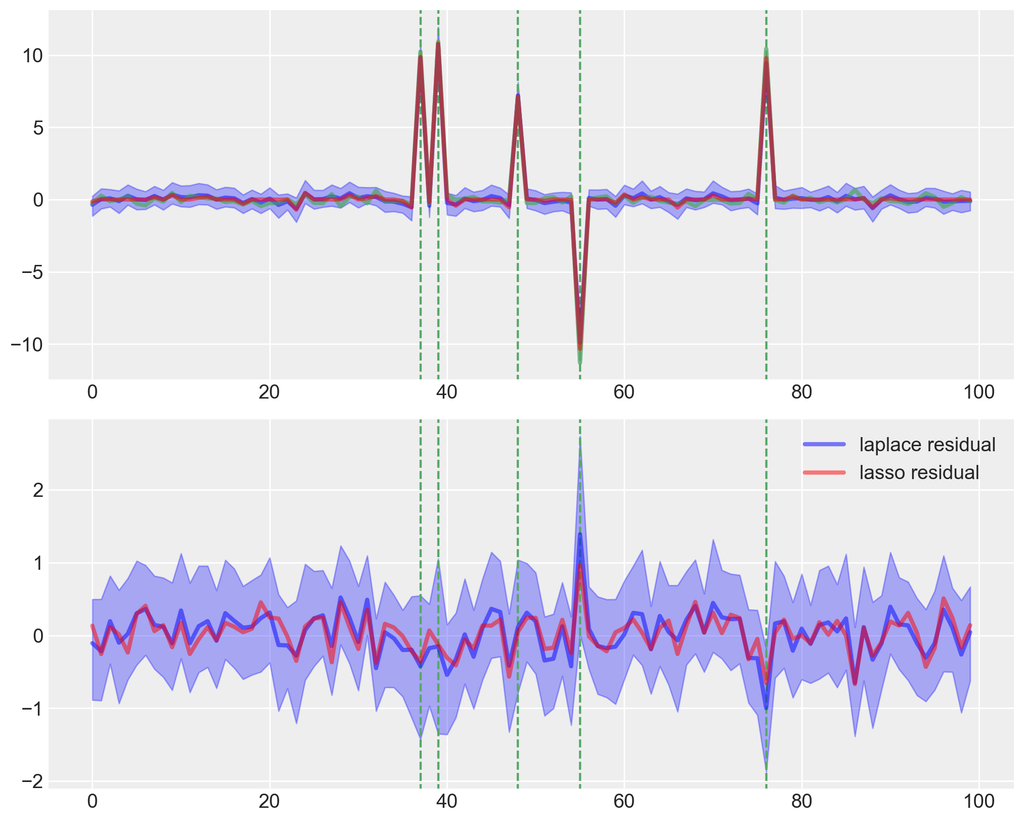

```python
f, ax = plt.subplots(2, figsize=(10,8))
pr.plot_coefficients(ax, theta_true, indices_support=indices_support, theta_hat=theta_laplace, lower_bound=lower_bound_laplace, upper_bound=upper_bound_laplace,
             color="blue", label="laplace")
pr.plot_coefficients(ax, theta_true, indices_support=indices_support, theta_hat=theta_lasso, color="red", label="lasso")
plt.show()
```

The Laplace prior usually tends to overregularize. Can you get rid of that problem playing with the parameters of the prior?

## Bayesian lasso using the horseshoe prior

We'll try to enforce some sparsity using a different prior, the ``horseshoe prior" of Carvalho et al. '10. This will force the whole posterior to put mass on sparse vectors, unlike the Laplace prior. Your next exercise is to repeat the steps of the Laplace prior for the horseshoe, and see what we gained/lost.

```python
trace_horseshoe = pr.get_mcmc_sample_for_horseshoe_prior(X, y)
```

```
Auto-assigning NUTS sampler...
Initializing NUTS using jitter+adapt_diag...
Multiprocess sampling (4 chains in 4 jobs)
NUTS: [theta, tau, lambda]
```

[output not shown]

[output cut: 28 more lines]

[output not shown]

```python
pm.summary(trace_horseshoe)
```

|  | mean | sd | hdi_3% | hdi_97% | mcse_mean | mcse_sd | ess_mean | ess_sd | ess_bulk | ess_tail | r_hat |
| --- | --- | --- | --- | --- | --- | --- | --- | --- | --- | --- | --- |
| theta[0] | -0.441 | 0.316 | -0.823 | 0.026 | 0.137 | 0.103 | 5.0 | 5.0 | 6.0 | 65.0 | 1.65 |
| theta[1] | 0.005 | 0.043 | -0.069 | 0.055 | 0.009 | 0.007 | 21.0 | 21.0 | 20.0 | 21.0 | 1.15 |
| theta[2] | 0.004 | 0.026 | -0.029 | 0.065 | 0.005 | 0.003 | 28.0 | 28.0 | 36.0 | 35.0 | 1.15 |
| theta[3] | -0.000 | 0.020 | -0.040 | 0.040 | 0.002 | 0.001 | 164.0 | 164.0 | 42.0 | 144.0 | 1.08 |
| theta[4] | -0.010 | 0.028 | -0.072 | 0.029 | 0.010 | 0.007 | 8.0 | 8.0 | 10.0 | 25.0 | 1.32 |
| ... | ... | ... | ... | ... | ... | ... | ... | ... | ... | ... | ... |
| horseshoe[95] | 0.046 | 0.147 | 0.000 | 0.161 | 0.016 | 0.012 | 79.0 | 79.0 | 28.0 | 79.0 | 1.31 |
| horseshoe[96] | 0.052 | 0.319 | 0.000 | 0.154 | 0.014 | 0.010 | 527.0 | 527.0 | 82.0 | 230.0 | 1.28 |
| horseshoe[97] | 0.024 | 0.073 | 0.000 | 0.083 | 0.008 | 0.006 | 85.0 | 85.0 | 13.0 | 56.0 | 1.24 |
| horseshoe[98] | 0.030 | 0.095 | 0.000 | 0.088 | 0.014 | 0.010 | 45.0 | 45.0 | 13.0 | 81.0 | 1.24 |
| horseshoe[99] | 0.033 | 0.096 | 0.000 | 0.110 | 0.006 | 0.004 | 242.0 | 242.0 | 26.0 | 139.0 | 1.13 |

301 rows × 11 columns

```python
l2_norm = np.array([np.linalg.norm(y - trace_horseshoe["theta"][i].dot(X.T)) for i in range(trace_horseshoe["theta"].shape[0])])
np.min(l2_norm)
```

```
5.980690755234817
```

```python
# Again, fill in the Bayesian estimator for the squared loss and credible intervals.
theta_horseshoe = np.mean(trace_horseshoe["theta"], axis=0) #trace['theta'][np.argmin(l2_norm)] # not expected to show much sparsity
lower_bound_horseshoe = np.percentile(trace_horseshoe["theta"],5, axis=0)
upper_bound_horseshoe = np.percentile(trace_horseshoe["theta"],95, axis=0)
```

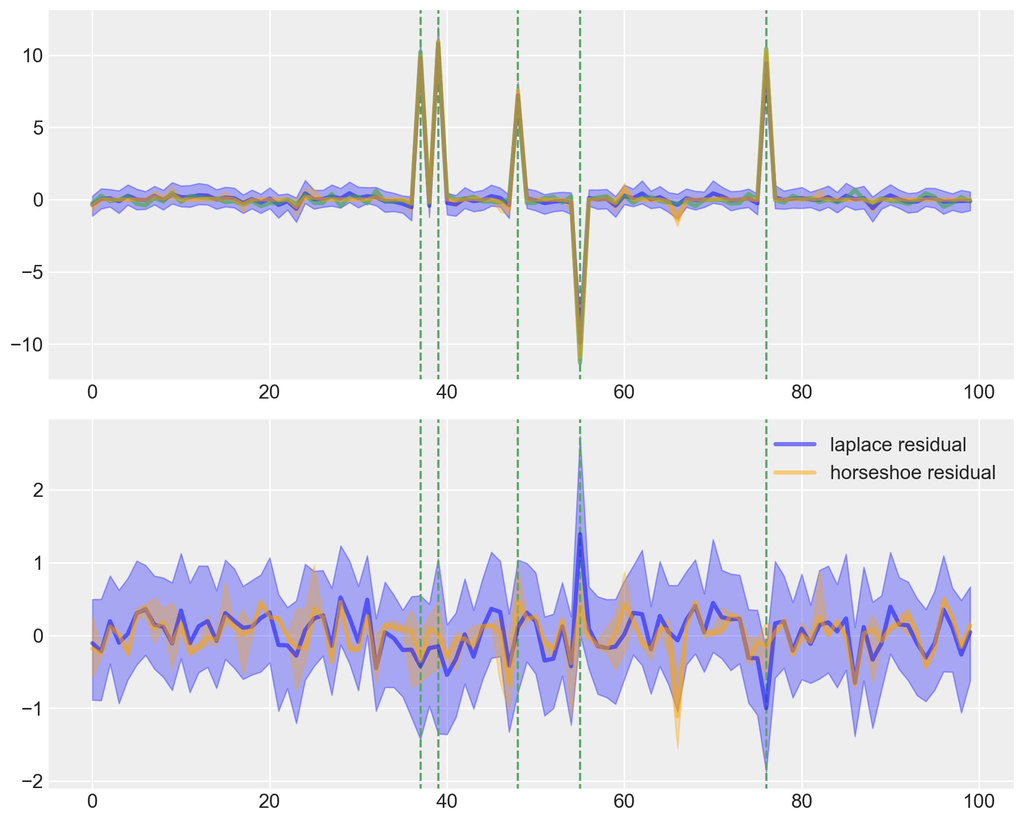

```python
# This will plot your estimates so far for comparison
f, ax = plt.subplots(2, figsize=(10,8))
pr.plot_coefficients(ax, theta_true, indices_support=indices_support, theta_hat=theta_laplace, lower_bound=lower_bound_laplace, upper_bound=upper_bound_laplace,
                        color="blue", label="laplace")
pr.plot_coefficients(ax, theta_true=theta_true, indices_support=indices_support, theta_hat=theta_horseshoe, lower_bound=lower_bound_horseshoe,
                     upper_bound=upper_bound_horseshoe, color="orange", label="horseshoe")
#pr.plot_coefficients(ax, theta_true=theta_true, indices_support=indices_support, theta_hat=theta_lasso, color='red', label="lasso")

plt.show()
```

## Bayesian lasso using the Finnish horseshoe prior

If you've made it so far, you've deserved to pick your last exercise: either

- find a dataset of your liking to which you apply the previous estimators.
- delve into more subtle priors, with, e.g. the Finnish horseshoe prior of [Piironen and Vehtari '17](https://arxiv.org/pdf/1707.01694.pdf). You can use the cells below.
- Try to learn more about HMC and its NUTS variant, the flagship MCMC kernel of `pymc3`. How are the HMC parameters tuned in NUTS? Can you prove that the resulting Markov kernel leaves the target distribution invariant?

```python
trace_finnish_horseshoe = pr.get_mcmc_sample_for_finnish_horseshoe_prior(X, y)
```

```
WARNING (theano.gof.compilelock): Overriding existing lock by dead process '37464' (I am process '35338')
Auto-assigning NUTS sampler...
Initializing NUTS using jitter+adapt_diag...
Multiprocess sampling (4 chains in 4 jobs)
NUTS: [c2_tilde, tau_tilde, lamda, beta_tilde]
```

100.00% [8000/8000 00:53<00:00 Sampling 4 chains, 640 divergences]

```
Sampling 4 chains for 1_000 tune and 1_000 draw iterations (4_000 + 4_000 draws total) took 64 seconds.
There were 22 divergences after tuning. Increase `target_accept` or reparameterize.
There were 15 divergences after tuning. Increase `target_accept` or reparameterize.
There were 595 divergences after tuning. Increase `target_accept` or reparameterize.
The acceptance probability does not match the target. It is 0.4680841511983436, but should be close to 0.8. Try to increase the number of tuning steps.
There were 8 divergences after tuning. Increase `target_accept` or reparameterize.
The rhat statistic is larger than 1.2 for some parameters.
The estimated number of effective samples is smaller than 200 for some parameters.
```

```python
l2_norm = np.array([np.linalg.norm(y - trace_finnish_horseshoe["theta"][i].dot(X.T)) for i in range(trace_finnish_horseshoe["theta"].shape[0])])
np.min(l2_norm)
```

```
4.635728470601592
```

```python
theta_finnish_horseshoe = np.mean(trace_finnish_horseshoe["theta"], axis=0)
lower_bound_finnish_horseshoe = np.percentile(trace_finnish_horseshoe["theta"],5, axis=0)
upper_bound_finnish_horseshoe = np.percentile(trace_finnish_horseshoe["theta"],95, axis=0)
```

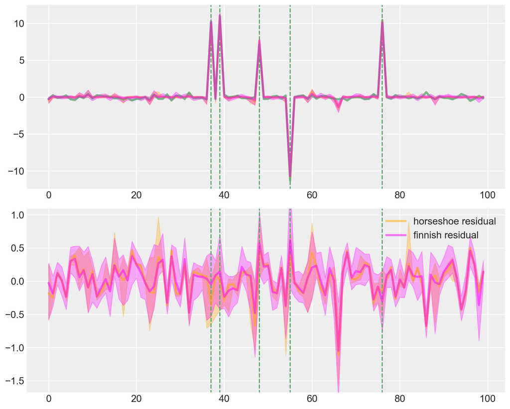

```python
f, ax = plt.subplots(2, figsize=(10,8))
#pr.plot_coefficients(ax, theta_true, indices_support=indices_support, theta_hat=theta_laplace,
#color="blue", label="laplace")
pr.plot_coefficients(ax, theta_true=theta_true, indices_support=indices_support, theta_hat=theta_horseshoe, lower_bound=lower_bound_horseshoe,
                     upper_bound=upper_bound_horseshoe, color="orange", label="horseshoe")
pr.plot_coefficients(ax, theta_true, indices_support=indices_support, theta_hat=theta_finnish_horseshoe, lower_bound=lower_bound_finnish_horseshoe,
                     upper_bound=upper_bound_finnish_horseshoe, color="magenta", label="finnish")
#pr.plot_coefficients(theta_true, theta_lasso, color="red", label="lasso")

plt.show()
```